# Mixed-Effects Modelling for MRI Batch Investigations

Eric Bridgeford

October 12, 2017

```r
# load packages
#==========================#
require(fmriutils)
require(VCA)
require(stringr)
require(lme4)
require(RColorBrewer)
require(oro.nifti)
require(reshape2)
require(latex2exp)
require(ggplot2)
require(Rmisc)

# functions
#==========================#

xscale.log2 <- function(a=3, b=6, n=10) {
  return(round(2^(seq(a, b, length.out=n))))
}

xscale.log10 <- function(a=1, b=3, n=10) {
  return(round(10^(seq(a, b, length.out=n))))
}
```

# Setting

## Task

Given:

- $n$ samples of data-tuples, $\left\{(g_i, y_i, z_i)\right\}_{i=1}^n$.
- A graph, $g_i \in G$, where $g_i = (E, V, w)$ for $N=|V|$ regions of interest and $w(v_i, v_j) = w_{ij}$.
- A set of fixed-effects, $y_i \in Y$, where $Y$ is the set of variables that we expect to impact magnitude differences in our observations.
- A set of random-effects, $z_i \in Z$, where $Z$ is a set of variables that will contribute random noise to our observations.

Characterize the composition of signal to batch-effect present in the given connectomes, assuming both the fixed-effects and random-effects can be characterized as random inputs in a standard mixed-effects model.

## Statistical Model

Assume that the desired signal at a given edge can be modelled as a linear combination of the fixed and random effects under the mixed-effects model:

$$\begin{align*}
w_{ij, \cdot} = Y\beta_{ij} + Zu_{ij} + \epsilon_{ij}
\end{align*}$$

where $w_{ij, \cdot}$ is the vector of connectome weights for the $ij^{th}$ edge.

Then: + $\mathbb{E}\left[w_{ij, \cdot}\right] = Y\beta_{ij}$ + $\beta_{ij}$ is an unknown vector of fixed-effects + $u_{ij}$ is an unknown vector of random-effects where $\mathbb{E}\left[u_{ij}\right] = 0$ and $var(u) = G_{ij}$ + $\epsilon_{ij}$ is an unknown vector of random errors, where $\mathbb{E}\left[\epsilon_{ij}\right] = 0$ and $var\left(\epsilon_{ij}\right) = R_{ij}$ + $Y$ and $Z$ are the known design matrices relating the observations $w_{ij, \cdot}$ to $\beta_{ij}$ and $u_{ij}$

### Models to be used

```
null_model: edgeweight ~ sex + age + (1 | subject)
alternative_model: edgeweight ~ sex + age + (1 | subject) + (1 | dataset)
```

That is, the null model specifies fixed effects for age and sex, and a random effect for subject. The alternative model specifies fixed effects for age and sex, and random effects for subject and dataset.

## Statistical Goal

Given that the joint density of $y$ and $u$ can be written $f(w_{ij, \cdot}, u_{ij}) = f(w_{ij, \cdot} | u_{ij}) f(u_{ij})$, assuming the normality and independence of our random-effects and errors, we can say that $u_{ij} \sim \mathcal{N}(0, G_{ij})$ and $\epsilon_{ij} \sim \mathcal{N}(0, R_{ij})$, and that $Cov(u_{ij}, \epsilon_{ij}) = 0$. Then we can use Henderson’s mixed model equations:

$$\begin{align*}
\begin{bmatrix}
Y^TR^{-1}_{ij}Y & Y^TR^{-1}_{ij}Z \\
Z^TR^{-1}_{ij}Y & Z^TR^{-1}_{ij}Z + G^{-1}_{ij} \\
\end{bmatrix} \begin{bmatrix}
\hat{\beta}_{ij} \\ \hat{u}_{ij}
\end{bmatrix} &=
\begin{bmatrix}
Y^TR^{-1}_{ij}w_{ij, \cdot} \\
Z^TR^{-1}_{ij}w_{ij, \cdot}
\end{bmatrix}
\end{align*}$$

where $\hat{u}$ and $\hat{\beta}$ are the best linear unbiased estimates for $\beta$ and $u$. We can solve for $\hat{\beta}$ and $\hat{u}$ using EM.

## Evaluation

### Akaike’s Information Criterion (AIC) for Determining Model Fit

Given $k$ the number of estimated parameters in the model and $L\left(w_{ij} | \hat{\beta}_{ij}, \hat{u}_{ij}\right)$ the maximum value of the likelihood function for the model, the Akaike’s information criterion can be defined:

$$\begin{align*}
A\left(w_{ij} | k, \hat{\beta}_{ij}, \hat{u}_{ij}\right) = 2k - 2ln\left(L\left(w_{ij} | \hat{\beta}_{ij}, \hat{u}_{ij}\right)\right)
\end{align*}$$

where $\hat{L}$ is the estimated fit of the mixed-effects model.

We will use the notation $\delta_A = A_m - A_n$ to denote the difference in the AIC between the null (without the dataset-labels as a random-effect) and the model (with the dataset-labels as a random-effect) in the below.

#### Test Statistic

[Paired T-Test](https://en.wikipedia.org/wiki/Welch%27s_t-test) for testing whether populations have equal means given that they have different variances in the univariate case.

$$\begin{align*}
T = \frac{\bar{D}}{\sqrt{\frac{s_M^2}{n_M} + \frac{s_N^2}{n_N}}}
\end{align*}$$

where $D$ is the collection $D_{ij} = A_{m, ij} - A_{n, ij}$ (that is, our test is paired).

and the degrees of freedom can be calculated as follows:

$$\begin{align*}
\nu &= \frac{\left(\frac{s_M^2}{n_M} + \frac{s_N^2}{n_N}\right)^2}{\frac{s_M^4}{n_M^2 \nu_M} + \frac{s_N^4}{n_N^2\nu_N}}
\end{align*}$$

where the standard deviation $s_j = \sqrt{\frac{p_j(1 - p_j)}{\left(\frac{N}{2}\right)^2}}$

where $\nu_1 = n_1 - 1, \; \nu_2 = n_2 - 1$.

We can then use a one-sided test given $T, \nu$ to get a $p-$ value.

#### P-Value

We can compute a p-value of falsely rejecting the null hypothesis by simply finding the area:

$$\begin{align*}
p = \int_{-T_{observed}}^{\infty}p(x, \nu) dx = 1 - \int_{-\infty}^{T_{observed}} p(x, \nu) dx
\end{align*}$$

where $p(x, \nu)$ is the pdf for the $T$ distribution with degrees of freedom $\nu$.

### Variance Accounted for by a Given Random Effect

We will look at the amount of variance that can be explained by a given random effect for each random effect present. That is, for each edge $ij$:

$$\begin{align*}
\phi_{k, ij} &= \frac{var(Z_k)}{\sum_{l=1}^K var(Z_l)}
\end{align*}$$

#### Variance Accounted for by a given Region in the Brain

To visualize the amount of variance accounted for by a given random-effect in each region of the brain, we will look at the average variance accounted for at all edges adjacent a given region. That is:

$$\begin{align*}
\Gamma_{k, i} &= \frac{1}{N}\sum_{j=1}^N \phi_{k, ij}
\end{align*}$$

This will allow us to think about the variance in terms of the per-region variance, and overlay the per-region variance per random-effect with the parcellation of the brain.

### Confidence that a given random-effect is significant

We are interested in the quantity of whether a given random-effect is significant. To accomplish this, we can formulate the hypothesis of whether $H_0 := \mu_1 = ... = \mu_K$; that is, the mean activity at each edge $\mu_i$ are the same across the $i$ groupings of our given random-effect of interest, with $H_A := \textrm{the means are not equal}$.

Particularly, we are concerned with whether the random-effect for the dataset (the site at which the scan associated with a given connectome was taken) has a significant impact on the resulting signal detected.

#### Test Statistic

This can be examined using the F-test statistic:

$$\begin{align*}
F &= \frac{\textrm{between-group variability}}{\textrm{within-group varaibility}} \\
&= \frac{\sum_{i=1}^K n_i (\bar{Y}i - \bar{Y})^2/(K - 1)}{\sum{i=1}^K\sum_{j=1}^{n_i} (Y_{ij} - \bar{Y_{i})^2}/(N - K)}
\end{align*}$$

#### P-Value

We can the compute the $p-$value where:

$$\begin{align*}
p = \mathbb{P}\left\{\textrm{Falsely reject $H_0$ for $H_A \; | \; H_0$ is true}\right\}
\end{align*}$$

This is equivalent to simply finding the area:

$$\begin{align*}
p = \int_{-F_{observed}(N-1, N-K)}^{\infty}p(x, N-1, N-K) dx = 1 - \int_{-\infty}^{F_{observed}} p(x, N-1, N-K) dx
\end{align*}$$

where $p(x, N-1, N-K)$ is the pdf for the $F$ distribution with degrees of freedom $N-1, N-K$.

# Simulations

In our simulations, we will investigate our ability to accurately identify the convergence of parameters estimated by our model to the true variances as we increase our number of samples in our dataset using the `lmer` package. We will begin with the following simulated example:

```
R ~ X + Y + (1 | Z) + (1 | Q) + Eps
```

where $X \in \{0, 1\}$ is a categorical fixed-effect to simulate sex, $Y$ is a continuous fixed-effect to simulate age, $Z$ and $Q$ are random-effects to simulate subject id and dataset id, and `Eps` is random error. All effects are assumed to be independent in this simple case.

In pseudo-code, we will perform:

```
+ for i in 1:5:
  + n = round(2^(i+1))  # log-base-2 scale of the numbers of possible observations
  Xids = sim(100, {0, 1})  # simulate n values for X
  Yids = sim(100, norm(mean=50, sd=20))  # simulate n variables with mean of 50
  Zids = sim(100, norm(mean=0, sd=sqrt(varz)))  # simulate n mean-0 varas with sd of sqrt(varz)
  Qids = sim(100, norm(mean=0, sd=sqrt(varq)))  # simulate n mean-0 varas with sd of sqrt(varq)
  Eps = sim(n, norm(mean=0, sd=sqrt(eps)))  # simulate n error terms
  R = 20*Xids + 5*Yids + Zids + Qids + Eps # sum to get Y
  fit.model = lmer(R ~ X + Y + (1 | Z) + (1 | Q))  # fit a model with Q
  fit.null = lmer(R ~ X + Y + (1 | Z))  # fit a null model without Q
  result = anova(fit.model, fit.null)  # determine the fit of the model with and without Q
  pr[i] = probability that the model is a better fit with Q than without
  er_params[i] = check the error of the estimated parameters and ratios of variances
show that the probability that Q positively impacts our model fit improves with larger n
show that our parameters for the intercepts and estimated variance converge with larger n
```

```r
no <- 8 # number of steps we will have
ns <- xscale.log2(a=7, b=10, n=no)  # number of samples
nrep <- 50  # number of replicates per n for our simulations to smooth our plots a bit
xsl <- 10  # slope of x
ysl <- 5  # slope of y
zstd <- 12  # std of z
qstd <- 10  # std of q
ervar <- 1  # error term
np <- 8  # resolution of our parameter sets
npars <- round(seq(10, 100, length.out=8))
aic_diff <- array(0, dim=c(no, np))  # make sure the model always fits better with q than without
xsl_er <- array(0, dim=c(no, np))
ysl_er <- array(0, dim=c(no, np))
zstd_er <- array(0, dim=c(no, np))
qstd_er <- array(0, dim=c(no, np))
aic_pr <- array(0, dim=c(no, np))

for (i in 1:length(ns)) {
  n <- ns[i]
  xsler <- array(0, dim=c(nrep))
  ysler <- array(0, dim=c(nrep))
  zstder <- array(0, dim=c(nrep))
  qstder <- array(0, dim=c(nrep))
  aicdiff <- array(0, dim=c(nrep))
  aicpr <- array(0, dim=c(nrep))
  for (k in 1:length(npars)) {
    nz <- npars[k]; nq <- npars[k]
    for (j in 1:nrep) {
      X <- rbinom(n=n, size=1, p=0.4)  # choose the xs as bernoulli
      Y = rnorm(n=n, mean=50, sd=10)  # choose the ys as continuous w mean 50
      # choose the means of the z and q labels
      zmeans <- rnorm(n=nz, mean=0, sd=zstd)
      qmeans <- rnorm(n=nq, mean=0, sd=qstd)
      # assign labels to each n randomly
      zsamp <- sample(nz, size=n, replace=TRUE)
      qsamp <- sample(nq, size=n, replace=TRUE)
      # for each n, assign a random z and q label, and use the means computed previously
      Z <- zmeans[zsamp]
      Q <- qmeans[qsamp]
      eps <- rnorm(n=n, mean=0, sd=ervar)
      result <- xsl*X + ysl*Y + Z + Q + eps
      data <- data.frame(d=result, x=X, y=Y, z=zsamp, q=qsamp)
      fit.model <- lmer(d ~ x + y + (1 | z) + (1 | q), data, REML=FALSE)  # model as above; use ML estimate
      modsum <- summary(fit.model)  # summarize the model
      xsler[j] <- abs(modsum$coefficients[2,1] - xsl)/xsl  # x slope er
      ysler[j] <- abs(modsum$coefficients[3,1] - ysl)/ysl  # y slope er
      zstder[j] <- abs(attributes(modsum$varcor$z)$stddev - zstd)/zstd  # z variance er
      qstder[j] <- abs(attributes(modsum$varcor$q)$stddev - qstd)/qstd  # q variance er
      fit.null <- lmer(d ~ x + y + (1 | z), data, REML=FALSE)  # model without q
      anres <- anova(fit.null, fit.model)  # compare the two models to check that the model with q is a better fit
      aicdiff[j] <- anres$AIC[2] - anres$AIC[1]  # model (which is [2]) should have a lower AIC, so we expect this to get more negative
      aicpr[j] <- anres$`Pr(>Chisq)`[2]  # pval of model with q should be near zero (significant WHP)
    }
    xsl_er[i, k] <- mean(xsler)
    ysl_er[i, k] <- mean(ysler)
    zstd_er[i, k] <- mean(zstder)
    qstd_er[i, k] <- mean(qstder)
    aic_diff[i, k] <- mean(aicdiff)
    aic_pr[i, k] <- mean(aicpr)
  }
}
```

We can visualize the results of our simulation, first checking our parameter estimate errors. We expect that as `n` increases, our parameter estimates will improve, and thus get closer to zero. We define the parameter estimate error for a param $p$ to be:

$$\begin{align*}
er(p) = \frac{|p_{empirical} - p_{analytical}|}{p_{analytical}}
\end{align*}$$

We first investigate the convergence of our parameters with respect to various measures of interest to verify that our intuition is correct. We visualize: + the convergence of our parameters with respect to sample size, intuitively expecting parameters relating to our fixed effects ($X$ and $Y$ slopes) to converge, whereas we anticipate no convergence of our random-effects parameters ($\sigma_z, \sigma_q$). + the convergence of our parameters with respect to the number of possible levels our random-effects can occupy. We expect that with more levels, we will be able to better estimate the variance of our given random-effect

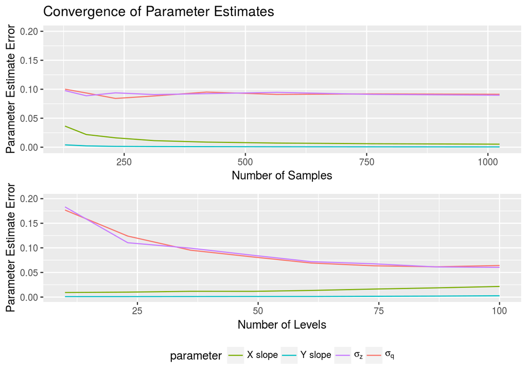

```r
param_dat <- data.frame(n=ns, xslope=apply(xsl_er, c(1), mean), yslope=apply(ysl_er, c(1), mean),
                        zstd=apply(zstd_er, c(1), mean), qstd=apply(qstd_er, c(1), mean))
param_dat <- as.data.frame.array(melt(param_dat, id=c("n")))
samp <- ggplot(param_dat, aes(x=n, y=value, color=variable)) +
  geom_line() +
  scale_color_discrete(name="parameter", breaks=c("xslope", "yslope", "zstd", "qstd"),
                      labels=lapply(c("X slope", "Y slope", "$\\sigma_z$", "$\\sigma_q$"), TeX)) +
  xlab("Number of Samples") +
  ylim(0, .2) +
  ylab("Parameter Estimate Error") +
  ggtitle("Convergence of Parameter Estimates") +
  theme(legend.position=NaN)

param_dat <- data.frame(n=npars, xslope=apply(xsl_er, c(2), mean), yslope=apply(ysl_er, c(2), mean),
                        zstd=apply(zstd_er, c(2), mean), qstd=apply(qstd_er, c(2), mean))
param_dat <- as.data.frame.array(melt(param_dat, id=c("n")))
cats <- ggplot(param_dat, aes(x=n, y=value, color=variable)) +
  geom_line() +
  scale_color_discrete(name="parameter", breaks=c("xslope", "yslope", "zstd", "qstd"),
                      labels=lapply(c("X slope", "Y slope", "$\\sigma_z$", "$\\sigma_q$"), TeX)) +
  xlab("Number of Levels") +
  ylim(0, .2) +
  ylab("Parameter Estimate Error") +
  theme(legend.position="bottom")

multiplot(samp, cats, cols=1)
```

Of note, we actaully fit our fixed-effects worse as the number of levels increases with fixed sample size. We might anticipate that this is because the model has more and more degrees of freedom for a fixed number of samples, and therefore may not converge as efficiently.

Additionally, we verify that tour model fit accounting for parameter `Q` is better than the model without `Q`. We do this in two ways: + verify that the difference between the model AIC with `Q`, $A_m$, is consistently less than the model AIC of the model without `Q`, $A_n$, and that as we increase sample size, the model with `Q` is a better and better fit (and hence, that the difference $A_m - A_n$ increases in magnitude and becomes more negative) + verify that the difference between the model AIC with `Q`, $A_m$, and the model AIC without `Q`, $A_n$, increases with the number of possible levels. This is because we expect that our model has more and more degrees of freedom, and therefore the model will fit worse and worse including more degrees of freedom (by including the `Q` parameter)

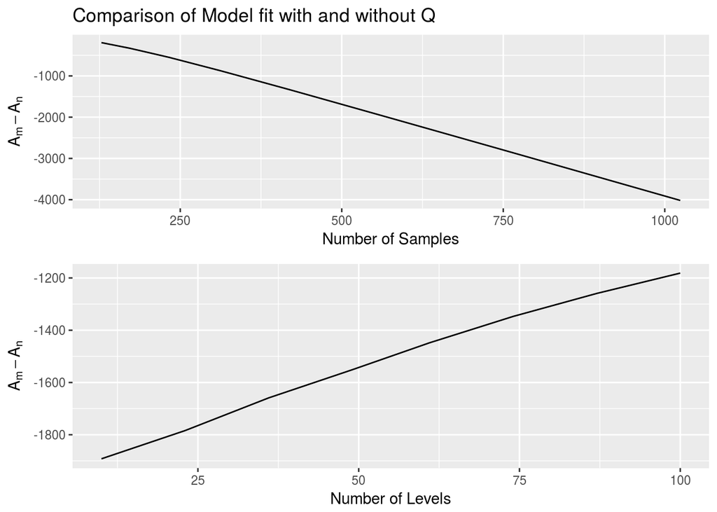

```r
dat_aicdiff <- data.frame(n=ns, diff=apply(aic_diff, c(1), mean))
samp <- ggplot(dat_aicdiff, aes(x=n, y=diff)) +
  geom_line() +
  xlab("Number of Samples") +
  ylab(TeX("$A_m - A_n$")) +
  ggtitle("Comparison of Model fit with and without Q")

dat_aicdiff <- data.frame(n=npars, diff=apply(aic_diff, c(2), mean))
cats <- ggplot(dat_aicdiff, aes(x=n, y=diff)) +
  geom_line() +
  xlab("Number of Levels") +
  ylab(TeX("$A_m - A_n$"))

multiplot(samp, cats, cols=1)
```

Finally, we look at the significance of including `Q` in the model, anticipating that with $p < 0.05$ we should have the inclusion of `Q` significantly impacting our model fit:

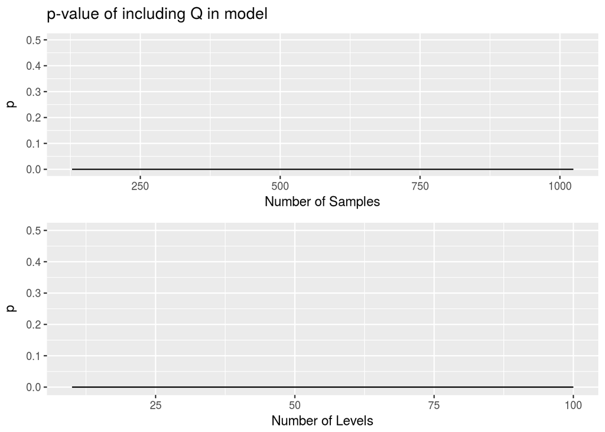

```r
dat_aicdiff <- data.frame(n=ns, diff=apply(aic_pr, c(1), mean))
samp <- ggplot(dat_aicdiff, aes(x=n, y=diff)) +
  geom_line() +
  xlab("Number of Samples") +
  ylab(TeX("$p$")) +
  ggtitle(TeX("$p$-value of including $Q$ in model")) +
  ylim(0, .5)

dat_aicdiff <- data.frame(n=npars, diff=apply(aic_pr, c(2), mean))
cats <- ggplot(dat_aicdiff, aes(x=n, y=diff)) +
  geom_line() +
  xlab("Number of Levels") +
  ylab(TeX("$p$")) +
  ylim(0, .5)

multiplot(samp, cats, cols=1)
```

as we can see, `Q` always improves our model significantly with $p < 0.05$.

## Takeaways

From our simulations, it is clear that we have a tradeoff in terms of the number of samples and the number of levels in our model. To accurately estimate a random-effect, we must have a large number of levels. However, this comes at the expense of decreasing the quality of our model fit as the DOF of the model increases. This leads to poorer convergence of the parameters of our fixed-effects, while simultaneously reducing the accuracy of our model to the true model the data is simulated from. Fortunately, this can be remedied by increasing our sample size. The estimates of our random-effects do not appear to “suffer” as we increase the sample size quite like the estimates of our fixed-effects/model suffered as we increased the number of levels. This means that in order to accurately apply this model to data, we will need a high number of levels per random-effect counter-balanced by a high number of samples.

# Real Data

## Diffusion

```r
nroi = 70
atlases = c("desikan")
dwi.dsets = c('BNU1', 'BNU3', 'HNU1', 'KKI2009', 'NKI1', 'Templeton114', 'SWU4')

graphobj <- fmriu.io.collection.open_graphs(basepath='/data/dwi/edgelists/', datasets = dwi.dsets,
                                            atlases = atlases, gname = "graphs", fmt='edgelist', rtype='array')
```

```
## [1] "opening graphs for BNU1 dataset and desikan parcellation atlas..."
## [1] "opening graphs for BNU3 dataset and desikan parcellation atlas..."
## [1] "opening graphs for HNU1 dataset and desikan parcellation atlas..."
## [1] "opening graphs for KKI2009 dataset and desikan parcellation atlas..."
## [1] "opening graphs for NKI1 dataset and desikan parcellation atlas..."
## [1] "opening graphs for Templeton114 dataset and desikan parcellation atlas..."
## [1] "opening graphs for SWU4 dataset and desikan parcellation atlas..."
```

```r
graphs = graphobj$graphs
```

```r
gcpy = graphs
datasets = graphobj$dataset
subjects = graphobj$subjects
sessions = graphobj$sessions

parse_class <- function(basepath, dsets, subjects) {
  sex = list()
  # disease = list()
  age = list()
  include = c()
  for (dset in dsets) {
    path_to_file = file.path(basepath, paste(dset, "_phenotypic_data.csv", sep=""))
    tab = read.csv(path_to_file)
    tab$SEX[tab$SEX == '#' | is.na(tab$SEX) | is.nan(tab$SEX)] = NaN
    if (dset == 'KKI2009') {
      sexm <- 'M'
    } else if (dset == 'Templeton114') {
      sexm <- 1
    } else {
      sexm <- 2
    }
    tab$AGE_AT_SCAN_1 <- factor(tab$AGE_AT_SCAN_1)
    tab$SEX = tab$SEX == sexm
    tab = tab[complete.cases(tab$SEX),]
    tab$AGE_AT_SCAN_1 = as.numeric(levels(tab$AGE_AT_SCAN_1))[tab$AGE_AT_SCAN_1]
    for (idx in 1:dim(tab)[1]) {
      subid = toString(tab[idx,]$SUBID)
      sex[[subid]] = tab[idx,]$SEX
      age[[subid]] = tab[idx,]$AGE_AT_SCAN_1
      # disease[[subid]] = tab[idx,]$DSM_IV_TR
    }
  }

  sclass = array(NaN, dim=c(length(subjects)))
  ageclass = sclass
  # diseaseclass = sclass
  for (i in 1:length(subjects)) {
    subject = subjects[i]
    subid = sub('^0+(?=[1-9])', '', str_extract(subject, '(?<=sub-).*'), perl=TRUE)
    idx = which(names(sex) == subid)
    if (length(idx) >= 1) {
      sclass[i] <- sex[[subid]]
      ageclass[i] <- age[[subid]]
      # diseaseclass[i] <- disease[[subid]]
    }
  }
  return(list(sex=sclass, age=ageclass))#, disease=diseaseclass))
}

sexpath = '/home/eric/Documents/research/MGC-repos/fmribatch_notes/data/phenotypic_data/'
class = parse_class(sexpath, dwi.dsets, subjects)
sexs = class$sex
# dwi.diseases = class$disease
ages = class$age

dwi.graphs = graphs[!is.nan(ages) & !is.nan(sexs),,]
dwi.datasets = datasets[!is.nan(ages) & !is.nan(sexs)]
dwi.subjects = subjects[!is.nan(ages) & !is.nan(sexs)]
dwi.sessions = sessions[!is.nan(ages) & !is.nan(sexs)]
dwi.ages = ages[!is.nan(ages) & !is.nan(sexs)]
dwi.sexs = sexs[!is.nan(ages) & !is.nan(sexs)]
```

```r
dwi.AIC.model = array(0, dim=c(nroi, nroi))
dwi.AIC.null = array(0, dim=c(nroi, nroi))
dwi.varest <- array(0, dim=c(nroi, nroi, 3))  # first for subject variance, second for dataset variance, third is error
test_dat = data.frame(sex=sexs, dataset=datasets, session=sessions, subject=subjects,
                      age=ages, dat=array(NaN, dim=c(length(subjects))))
dwi.dset_p <- array(0, dim=c(nroi, nroi))

for (i in 1:(nroi - 1)) {
  for (j in (i+1):nroi) {
    test_dat$dat <- graphs[,i,j]
    tryCatch({
      fit.model <- lmer(dat~sex + age + (1 | subject) + (1 | dataset), data=test_dat, REML=FALSE)
      fit.null <- lmer(dat~sex + age + (1 | subject), data=test_dat, REML=FALSE)
      dwi.AIC.model[i, j] <- AIC(fit.model)
      dwi.AIC.null[i, j] <- AIC(fit.null)
      modelsum <- summary(fit.model)
      dwi.varest[i,j,1] <- attributes(modelsum$varcor$subject)$stddev
      dwi.varest[i,j,2] <- attributes(modelsum$varcor$dataset)$stddev
      dwi.varest[i,j,3] <- modelsum$sigma
      dwi.dset_p[i, j] <- anova(fit.model, fit.null)$`Pr(>Chisq)`[2]
    }, error=function(e) {
    })
  }
}

dwi.AIC.model <- dwi.AIC.model + t(dwi.AIC.model)
dwi.AIC.null <- dwi.AIC.null + t(dwi.AIC.null)
dwi.varest[,,1] <- dwi.varest[,,1] + t(dwi.varest[,,1])
dwi.varest[,,2] <- dwi.varest[,,2] + t(dwi.varest[,,2])
dwi.varest[,,3] <- dwi.varest[,,3] + t(dwi.varest[,,3])
dwi.dset_p <- dwi.dset_p + t(dwi.dset_p)
```

We can plot the percent variance per random component:

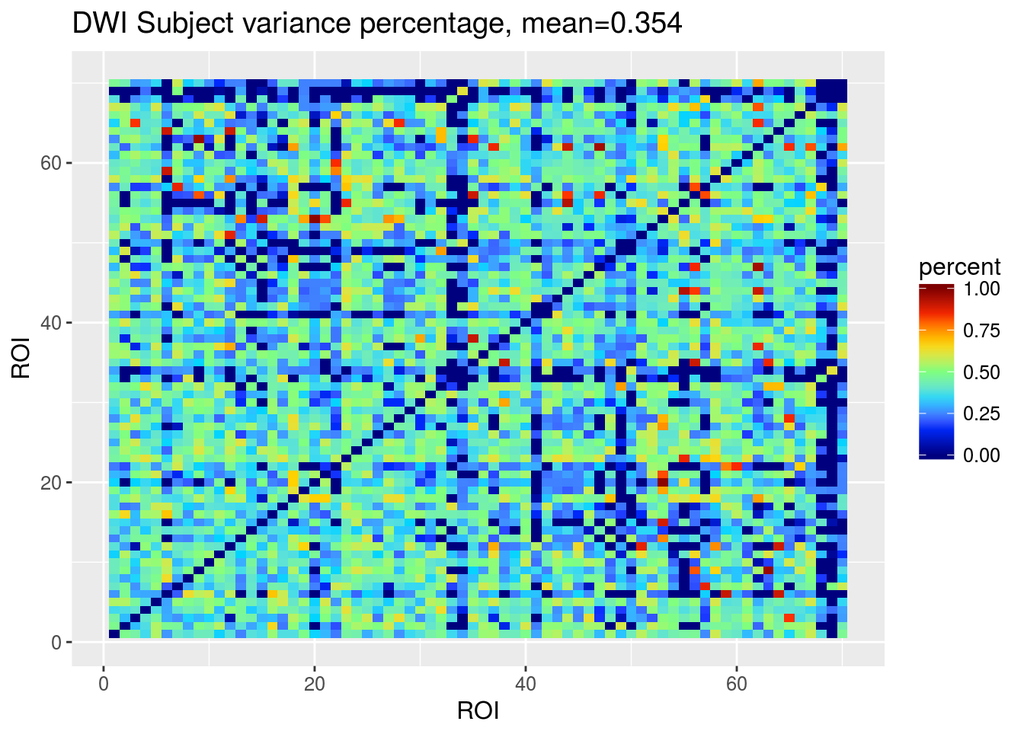

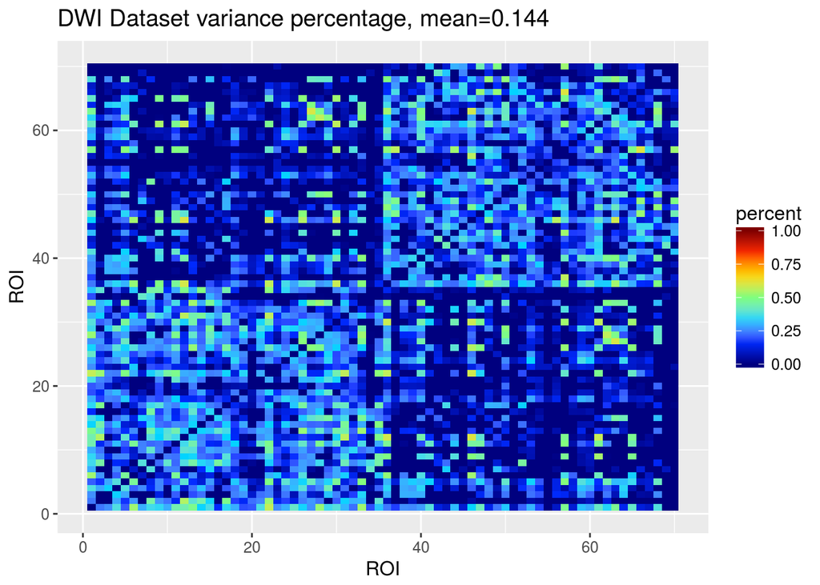

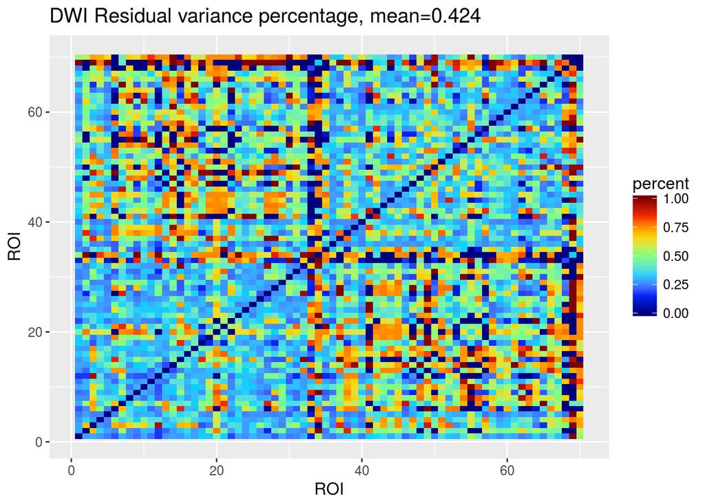

```r
varsrc <- c("Subject", "Dataset", "Residual")
dwi.varest[is.nan(dwi.varest)] <- 0
varcorrect <- 1/apply(dwi.varest, c(1,2), sum)
varcorrect[is.infinite(varcorrect)] = 1
for (i in 1:3){
  dat <- dwi.varest[,,i]*varcorrect
  print(fmriu.plot.plot_graph(dat,  legend.name='percent', title=sprintf("DWI %s variance percentage, mean=%.3f", varsrc[i],
                                                                         mean(dat[!is.nan(dat)])), limits = c(0, 1)))
}
```

And we can look at the probability that the dataset is a significant random-effect in the model:

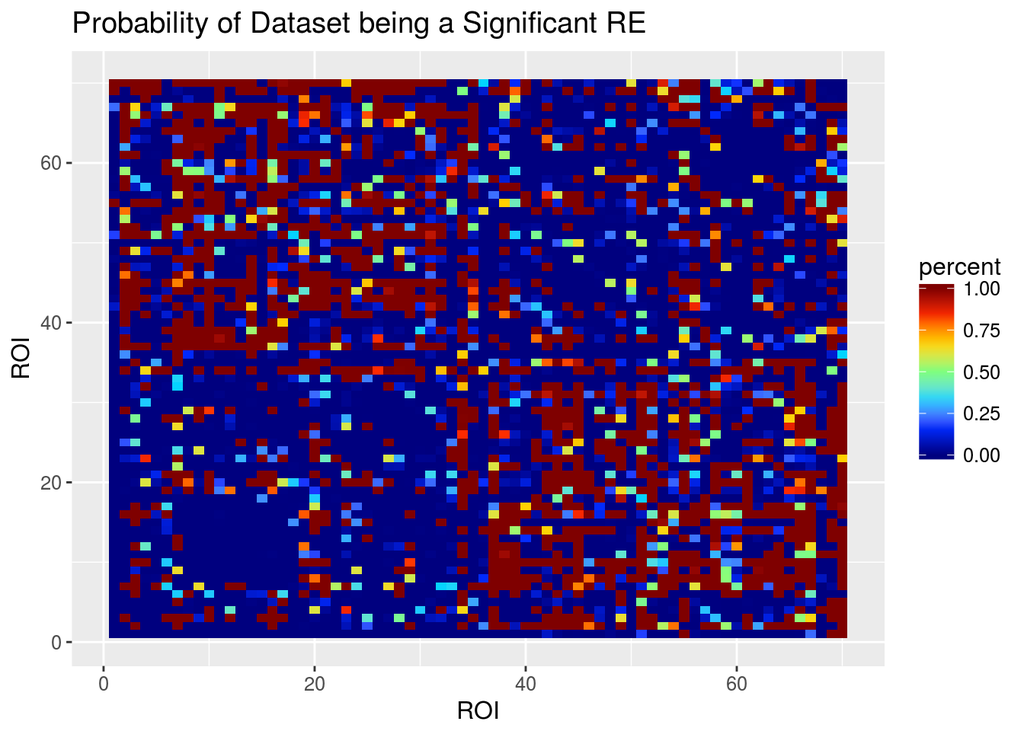

```r
print(fmriu.plot.plot_graph(dwi.dset_p,  legend.name='percent', title="Probability of Dataset being a Significant RE", limits = c(0, 1)))
```

Below, we plot the per-vertex average variance percentage, with respect to subject, dataset, and residual:

```
## [1] "Subject"
```

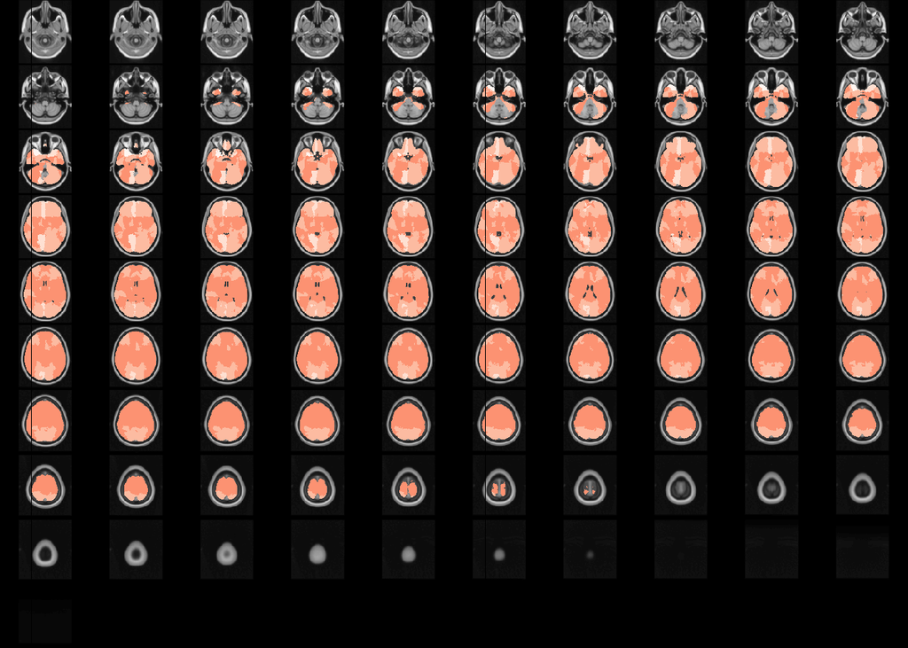

```
## NULL
## [1] "Dataset"
```

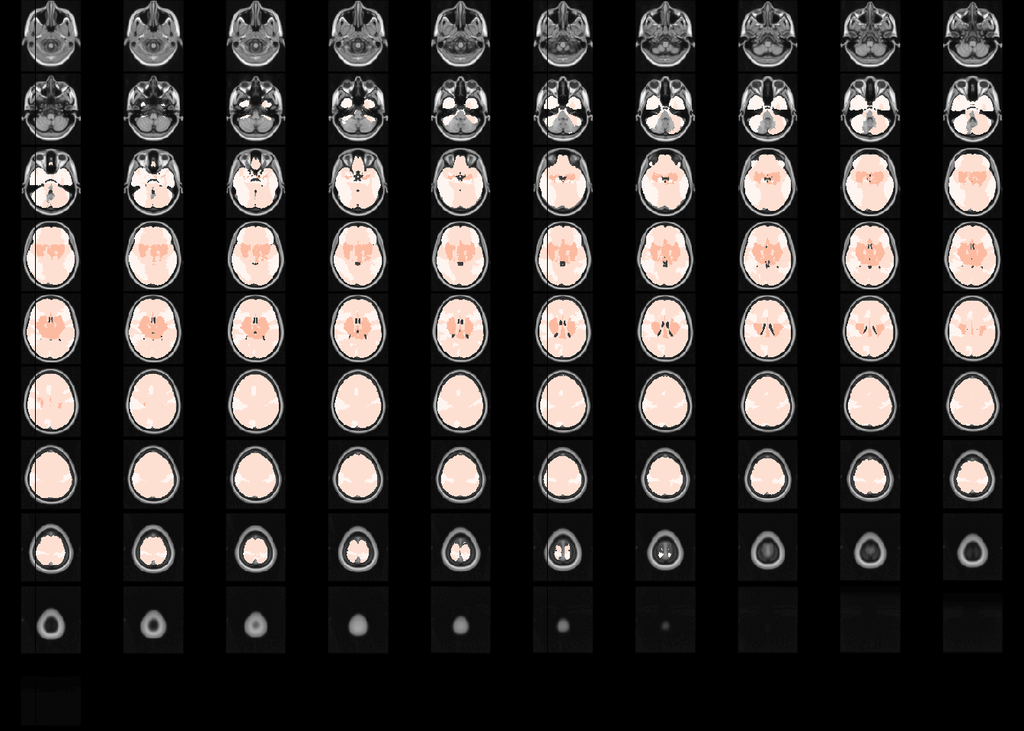

```
## NULL
## [1] "Residual"
```

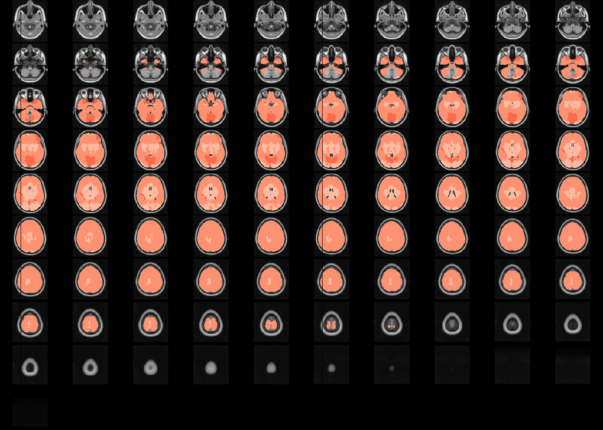

```r
# atlas is a oro.nifti image
plot_brain_overlay <- function(atlas, reference, values) {
  ov <- atlas
  # sort the rois so that they go low to small, which is what pipeline outputs
  roimap <- sort(unique(array(atlas@.Data)))
  roimap <- roimap[2:length(roimap)]  # ignore 0 valued roi (no region)
  for (roi in 1:length(values)) {
    if (is.nan(values[roi])) {
      ov@.Data[round(atlas@.Data) == roimap[roi]] = 0
    } else {
      ov@.Data[round(atlas@.Data) == roimap[roi]] = values[roi]
    }
  }
  overlay(reference, ifelse(ov > 0, ov, NA), zlim.y=c(0, length(values)),
          col.y=brewer.pal(n = 8, name = "Reds"))
}
parc = readNIfTI('/home/eric/atlases/func_atlases/label/desikan-res-2x2x2.nii.gz')
template = readNIfTI('/home/eric/atlases/func_atlases/atlas/MNI152NLin6_res-2x2x2_T1w.nii.gz')

for (i in 1:3) {
  vertvar = apply(dwi.varest[,,i]*varcorrect, 1, sum)
  print(varsrc[i])
  print(plot_brain_overlay(parc, template, vertvar))
}
```

Finally, we look at the model fit including the `dataset` parameter and without:

```r
dwi.AIC.model <- as.vector(dwi.AIC.model[!is.infinite(dwi.AIC.model) & ! is.infinite(dwi.AIC.null)])
dwi.AIC.null <- as.vector(dwi.AIC.null[!is.infinite(dwi.AIC.null) & !is.infinite(dwi.AIC.model)])
```

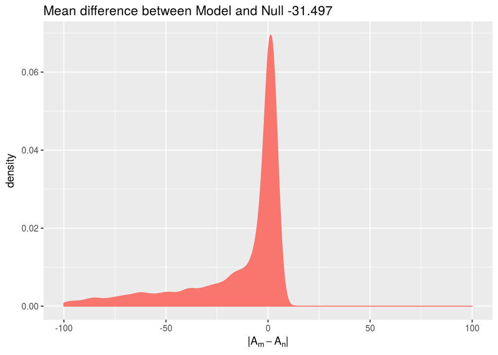

```r
diff = dwi.AIC.model - dwi.AIC.null

dat <- data.frame(model="difference", diff=diff)

ggplot(dat, aes(diff, color=model, fill=model)) +
  geom_density() +
  xlim(-100, 100) +
  xlab(TeX('$|A_m - A_n|$')) +
  ggtitle(sprintf('Mean difference between Model and Null %.3f', mean(diff))) +
  theme(legend.position=NaN)
```

```r
wilcox.test(dwi.AIC.model, dwi.AIC.null, alternative="less", paired=TRUE)
```

```
##
##  Wilcoxon signed rank test with continuity correction
##
## data:  dwi.AIC.model and dwi.AIC.null
## V = 2195400, p-value < 2.2e-16
## alternative hypothesis: true location shift is less than 0
```

as we can see, we obtain a $p$-value of near $0$ indicating a significantly better fit at $\alpha=0.5$.

## Functional

```r
nroi = 70
atlases = c('desikan-2mm')
require(fmriutils)
require(VCA)
require(stringr)

fmri.dsets = c('BNU1', 'BNU2', 'BNU3', 'HNU1', 'IBATRT', 'IPCAS1', 'IPCAS2', 'IPCAS5', 'IPCAS6', 'IPCAS8',
               'NYU1', 'SWU1', 'SWU2', 'SWU3', 'SWU4', 'UWM', 'XHCUMS')

graphobj <- fmriu.io.collection.open_graphs(basepath='/data/fmri/raw/edgelists/', datasets = fmri.dsets,
                                            atlases = atlases, fmt='edgelist', rtype='array')
```

```
## [1] "opening graphs for BNU1 dataset and desikan-2mm parcellation atlas..."
## [1] "opening graphs for BNU2 dataset and desikan-2mm parcellation atlas..."
## [1] "opening graphs for BNU3 dataset and desikan-2mm parcellation atlas..."
## [1] "opening graphs for HNU1 dataset and desikan-2mm parcellation atlas..."
## [1] "opening graphs for IBATRT dataset and desikan-2mm parcellation atlas..."
## [1] "opening graphs for IPCAS1 dataset and desikan-2mm parcellation atlas..."
## [1] "opening graphs for IPCAS2 dataset and desikan-2mm parcellation atlas..."
## [1] "opening graphs for IPCAS5 dataset and desikan-2mm parcellation atlas..."
## [1] "opening graphs for IPCAS6 dataset and desikan-2mm parcellation atlas..."
## [1] "opening graphs for IPCAS8 dataset and desikan-2mm parcellation atlas..."
## [1] "opening graphs for NYU1 dataset and desikan-2mm parcellation atlas..."
## [1] "opening graphs for SWU1 dataset and desikan-2mm parcellation atlas..."
## [1] "opening graphs for SWU2 dataset and desikan-2mm parcellation atlas..."
## [1] "opening graphs for SWU3 dataset and desikan-2mm parcellation atlas..."
## [1] "opening graphs for SWU4 dataset and desikan-2mm parcellation atlas..."
## [1] "opening graphs for UWM dataset and desikan-2mm parcellation atlas..."
## [1] "opening graphs for XHCUMS dataset and desikan-2mm parcellation atlas..."
```

```r
graphs = graphobj$graphs
```

```r
gcpy = graphs
datasets = graphobj$dataset
subjects = graphobj$subjects
sessions = graphobj$sessions

parse_class <- function(basepath, dsets, subjects) {
  sex = list()
  # disease = list()
  age = list()
  include = c()
  for (dset in dsets) {
    path_to_file = file.path(basepath, paste(dset, "_phenotypic_data.csv", sep=""))
    tab = read.csv(path_to_file)
    tab$SEX[tab$SEX == '#' | is.na(tab$SEX) | is.nan(tab$SEX)] = NaN
    if (dset == 'KKI2009') {
      sexm <- 'M'
    } else if (dset == 'Templeton114') {
      sexm <- 1
    } else {
      sexm <- 2
    }
    tab$AGE_AT_SCAN_1 <- factor(tab$AGE_AT_SCAN_1)
    tab$SEX = tab$SEX == sexm
    tab = tab[complete.cases(tab$SEX),]
    tab$AGE_AT_SCAN_1 = as.numeric(levels(tab$AGE_AT_SCAN_1))[tab$AGE_AT_SCAN_1]
    for (idx in 1:dim(tab)[1]) {
      subid = toString(tab[idx,]$SUBID)
      sex[[subid]] = tab[idx,]$SEX
      age[[subid]] = tab[idx,]$AGE_AT_SCAN_1
      # disease[[subid]] = tab[idx,]$DSM_IV_TR
    }
  }

  sclass = array(NaN, dim=c(length(subjects)))
  ageclass = sclass
  # diseaseclass = sclass
  for (i in 1:length(subjects)) {
    subject = subjects[i]
    subid = sub('^0+(?=[1-9])', '', str_extract(subject, '(?<=sub-).*'), perl=TRUE)
    idx = which(names(sex) == subid)
    if (length(idx) >= 1) {
      sclass[i] <- sex[[subid]]
      ageclass[i] <- age[[subid]]
      # diseaseclass[i] <- disease[[subid]]
    }
  }
  return(list(sex=sclass, age=ageclass))#, disease=diseaseclass))
}

sexpath = '/home/eric/Documents/research/MGC-repos/fmribatch_notes/data/phenotypic_data/'
class = parse_class(sexpath, fmri.dsets, subjects)
sexs = class$sex
# dwi.diseases = class$disease
ages = class$age

fmri.graphs = graphs[!is.nan(ages) & !is.nan(sexs),,]
fmri.datasets = datasets[!is.nan(ages) & !is.nan(sexs)]
fmri.subjects = subjects[!is.nan(ages) & !is.nan(sexs)]
fmri.sessions = sessions[!is.nan(ages) & !is.nan(sexs)]
fmri.ages = ages[!is.nan(ages) & !is.nan(sexs)]
fmri.sexs = sexs[!is.nan(ages) & !is.nan(sexs)]
```

```r
fmri.AIC.model = array(0, dim=c(nroi, nroi))
fmri.AIC.null = array(0, dim=c(nroi, nroi))
fmri.varest <- array(0, dim=c(nroi, nroi, 3))  # first for subject variance, second for dataset variance, third is error
test_dat = data.frame(sex=sexs, dataset=datasets, session=sessions, subject=subjects,
                      age=ages, dat=array(NaN, dim=c(length(subjects))))
fmri.dset_p <- array(0, dim=c(nroi, nroi))

for (i in 1:(nroi - 1)) {
  for (j in (i+1):nroi) {
    test_dat$dat <- graphs[,i,j]
    tryCatch({
      fit.model <- lmer(dat~sex + age + (1 | subject) + (1 | dataset), data=test_dat, REML=FALSE)
      fit.null <- lmer(dat~sex + age + (1 | subject), data=test_dat, REML=FALSE)
      fmri.AIC.model[i, j] <- AIC(fit.model)
      fmri.AIC.null[i, j] <- AIC(fit.null)
      modelsum <- summary(fit.model)
      fmri.varest[i,j,1] <- attributes(modelsum$varcor$subject)$stddev
      fmri.varest[i,j,2] <- attributes(modelsum$varcor$dataset)$stddev
      fmri.varest[i,j,3] <- modelsum$sigma
      fmri.dset_p[i, j] <- anova(fit.model, fit.null)$`Pr(>Chisq)`[2]
    }, error=function(e) {
    })
  }
}

fmri.AIC.model <- fmri.AIC.model + t(fmri.AIC.model)
fmri.AIC.null <- fmri.AIC.null + t(fmri.AIC.null)
fmri.varest[,,1] <- fmri.varest[,,1] + t(fmri.varest[,,1])
fmri.varest[,,2] <- fmri.varest[,,2] + t(fmri.varest[,,2])
fmri.varest[,,3] <- fmri.varest[,,3] + t(fmri.varest[,,3])
fmri.dset_p <- fmri.dset_p + t(fmri.dset_p)
```

We can plot the percent variance per random component:

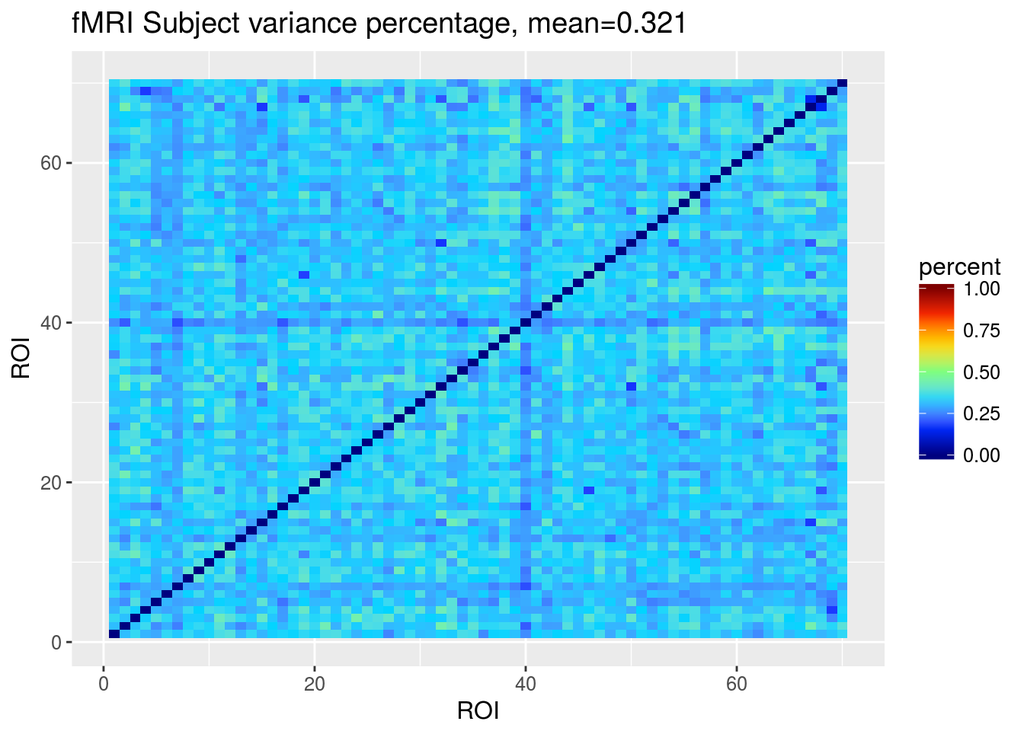

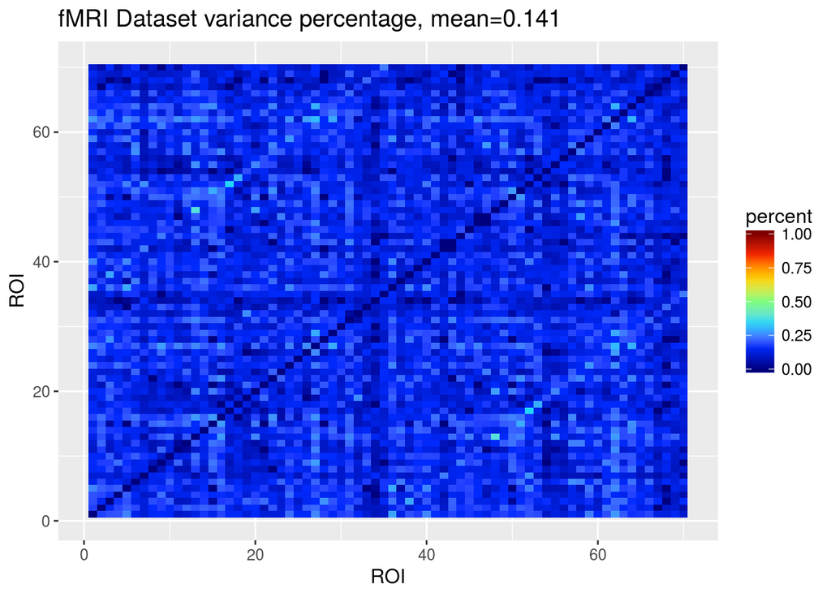

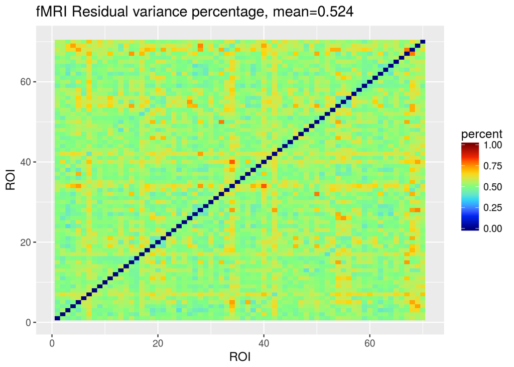

```r
varsrc <- c("Subject", "Dataset", "Residual")
fmri.varest[is.nan(fmri.varest)] <- 0
varcorrect <- 1/apply(fmri.varest, c(1,2), sum)
varcorrect[is.infinite(varcorrect)] = 1
for (i in 1:3){
  dat <- fmri.varest[,,i]*varcorrect
  print(fmriu.plot.plot_graph(dat,  legend.name='percent',
                             title=sprintf("fMRI %s variance percentage, mean=%.3f", varsrc[i],
                                           mean(dat[!is.nan(dat)])), limits = c(0, 1)))
}
```

And we can look at the probability that the dataset is a significant random-effect in the model:

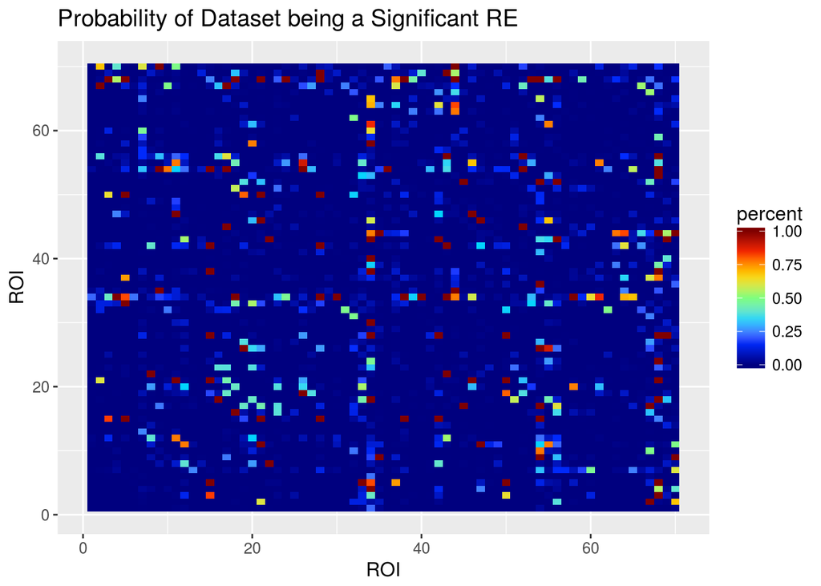

```r
print(fmriu.plot.plot_graph(fmri.dset_p,  legend.name='percent',
                            title="Probability of Dataset being a Significant RE", limits = c(0, 1)))
```

Below, we plot the per-vertex average variance percentage, with respect to subject, dataset, and residual:

```
## [1] "Subject"
```

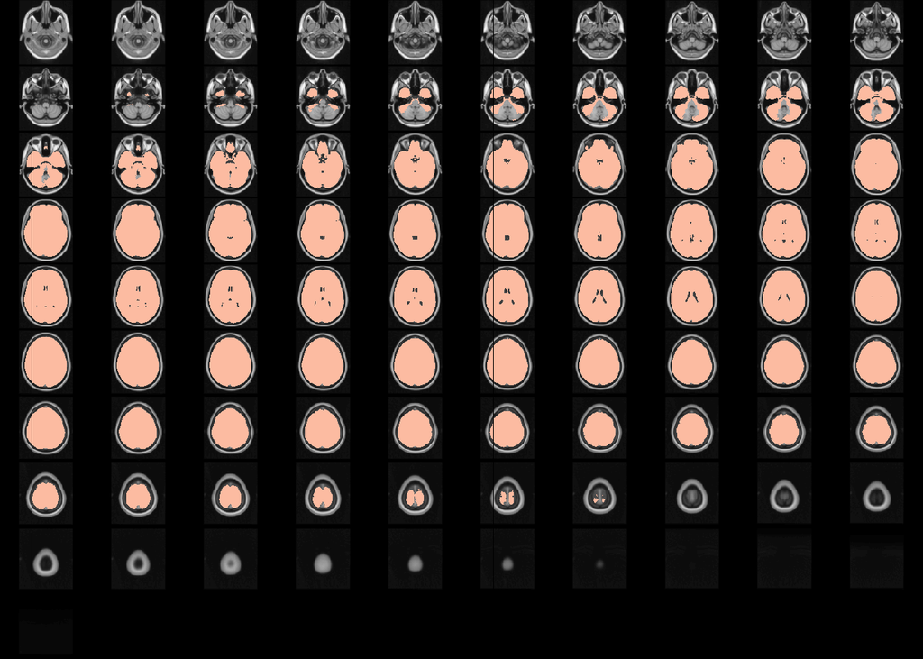

```
## [1] "Dataset"
```

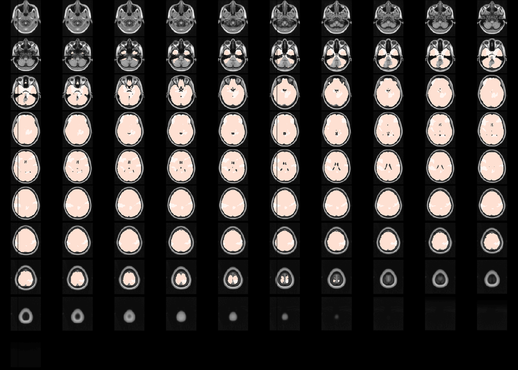

```
## [1] "Residual"
```

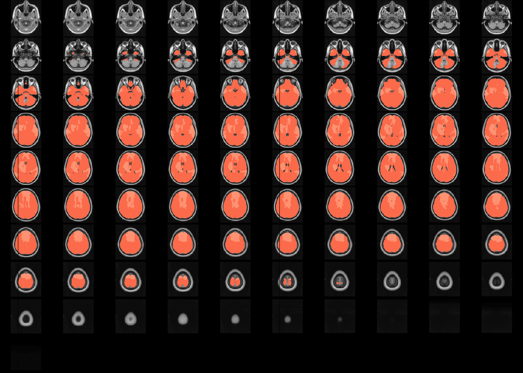

```r
# atlas is a oro.nifti image
plot_brain_overlay <- function(atlas, reference, values) {
  ov <- atlas
  # sort the rois so that they go low to small, which is what pipeline outputs
  roimap <- sort(unique(array(atlas@.Data)))
  roimap <- roimap[2:length(roimap)]  # ignore 0 valued roi (no region)
  for (roi in 1:length(values)) {
    if (is.nan(values[roi])) {
      ov@.Data[round(atlas@.Data) == roimap[roi]] = 0
    } else {
      ov@.Data[round(atlas@.Data) == roimap[roi]] = values[roi]
    }
  }
  overlay(reference, ifelse(ov > 0, ov, NA), zlim.y=c(0, length(values)),
          col.y=brewer.pal(n = 8, name = "Reds"))
}
parc = readNIfTI('/home/eric/atlases/func_atlases/label/desikan-res-2x2x2.nii.gz')
template = readNIfTI('/home/eric/atlases/func_atlases/atlas/MNI152NLin6_res-2x2x2_T1w.nii.gz')

for (i in 1:3) {
  vertvar = apply(fmri.varest[,,i]*varcorrect, 1, sum)
  print(varsrc[i])
  plot_brain_overlay(parc, template, vertvar)
}
```

Finally, we look at the model fit including the `dataset` parameter and without:

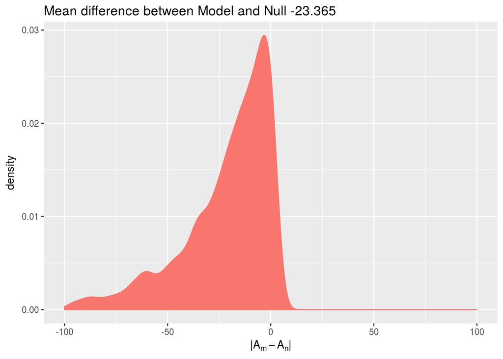

```r
fmri.AIC.model <- as.vector(fmri.AIC.model[!is.infinite(fmri.AIC.model) & ! is.infinite(fmri.AIC.null)])
fmri.AIC.null <- as.vector(fmri.AIC.null[!is.infinite(fmri.AIC.null) & !is.infinite(fmri.AIC.model)])
diff = fmri.AIC.model - fmri.AIC.null

dat <- data.frame(model="difference", diff=diff)

ggplot(dat, aes(diff, color=model, fill=model)) +
  geom_density() +
  xlim(-100, 100) +
  xlab(TeX('$|A_m - A_n|$')) +
  ggtitle(sprintf('Mean difference between Model and Null %.3f', mean(diff))) +
  theme(legend.position=NaN)
```

```r
wilcox.test(fmri.AIC.model, fmri.AIC.null, alternative="less", paired=TRUE)
```

```
##
##  Wilcoxon signed rank test with continuity correction
##
## data:  fmri.AIC.model and fmri.AIC.null
## V = 147030, p-value < 2.2e-16
## alternative hypothesis: true location shift is less than 0
```

as we can see, we obtain a $p$-value of near $0$ indicating a significantly better fit at $\alpha=0.5$.